# Modeling and prediction for movies

Michelle Tan

5/24/2018

```r
library(ggplot2)
library(dplyr)
library(statsr)
```

### Load data

```r
load("~/statistical  with R /Linear Regression and Modeling Movies/movies.Rdata")
```

## Part 2: Research question

Investigate what parameters are major influences on the audience score (audience_score.) Parameters are pulled from the movies data set.

If a meaninguful predection could be pulled from this exercise, I would be interested to repurpose this concept onto video game ratings, a form of media I am passionate about.

Scope of Inference

For the purposes of inference, this shoud be considered an observational study that uses a random sampling approach to obtain a representative sample from U.S. movies released between 1974 and 2016. Since a random sampling method is applied in data collection, the results can be generalizable to the movies released between 1974 and 2016.

Causation can only be inferred from a randomized experiment. This study does not meet the requirements of a randomized experiment, therefore causation can not be determined.

Sources of Bias

As Rotten Tomatoes audience score is created by voulnteers, the study may suffer from voluntary response bias since people with strong responses are more likely to participate. The voluntary participants may not be representative of the U.S. population.

## Part 3: Exploratory data analysis

The following features will be included in the first itteration of the multi linear regression model.

audience_score,genre,thtr_rel_month,imdb_rating,critics_score,best_pic_nom,best_actor_win,best_actress_win,top200_box

Data Pair Plots

The response variable will be audience_score.

The linear relationship between critics_score and audience_score and imdb_rating and audience_score lead the analyst to believe those data points would have the highest impact on audience score in future lienar models created in this analysis.

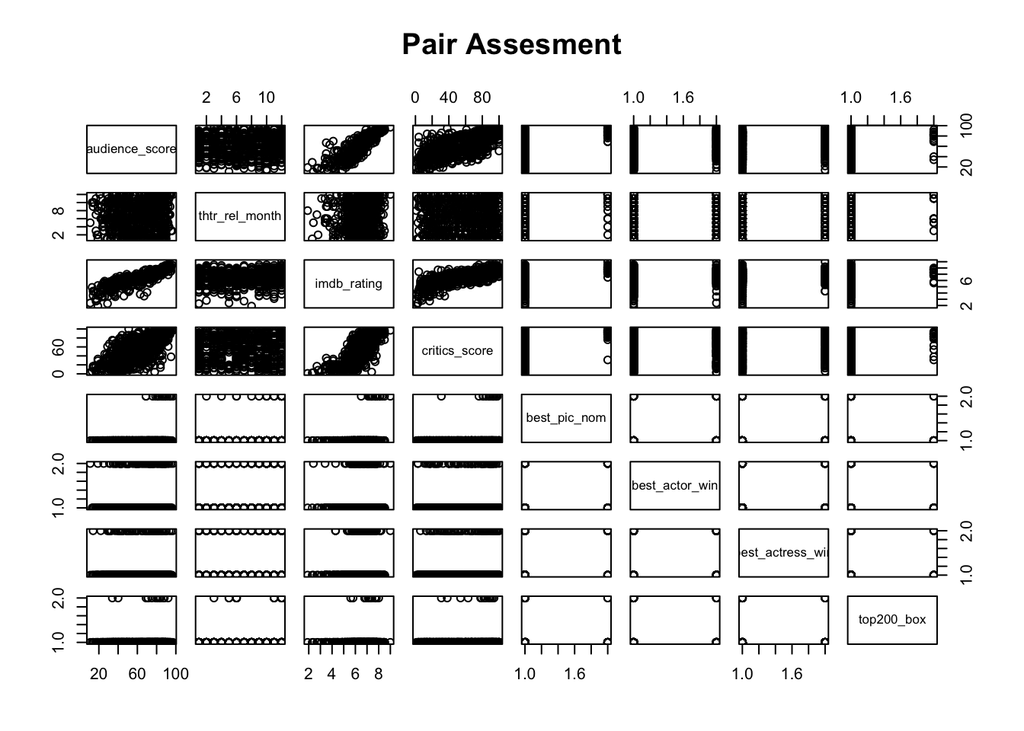

```r
workingset = select(movies, audience_score,genre,thtr_rel_month,imdb_rating,critics_score,best_pic_nom,best_actor_win,best_actress_win,top200_box)
workingset = na.exclude(workingset)
pairs(~audience_score+thtr_rel_month+imdb_rating+critics_score+best_pic_nom+best_actor_win+best_actress_win+top200_box,
      data=workingset,
   main="Pair Assesment")
```

## Part 4: Modeling

In this project we will use linear regression and start by fitting a model with 9 variables(described in the previous section). Backward elimination will help us to define if better results can be obtained by using a smaller set of attributes. The advantage of backward elimination is that it allows to start with all the variables, deleting one variable at a time until there are no improvements in the model.

First, let’s fit an initial model with the 9 variables. The adjusted R-squared is 76.68%.

```r
model<-lm(audience_score~genre+thtr_rel_month+imdb_rating+critics_score+best_pic_nom+best_actor_win+best_actress_win+top200_box,data=workingset)
summary(model)
```

```
##
## Call:
## lm(formula = audience_score ~ genre + thtr_rel_month + imdb_rating +
##     critics_score + best_pic_nom + best_actor_win + best_actress_win +
##     top200_box, data = workingset)
##
## Residuals:
##     Min      1Q  Median      3Q     Max
## -27.100  -6.198   0.343   5.584  50.082
##
## Coefficients:
##                                 Estimate Std. Error t value Pr(>|t|)
## (Intercept)                    -35.48683    3.17716 -11.169  < 2e-16 ***
## genreAnimation                   9.72637    3.49086   2.786  0.00549 **
## genreArt House & International   0.22529    2.90339   0.078  0.93818
## genreComedy                      2.44484    1.62145   1.508  0.13210
## genreDocumentary                 1.43704    1.99090   0.722  0.47068
## genreDrama                       0.27363    1.40151   0.195  0.84527
## genreHorror                     -5.06609    2.38562  -2.124  0.03409 *
## genreMusical & Performing Arts   4.89165    3.13877   1.558  0.11962
## genreMystery & Suspense         -5.67166    1.80100  -3.149  0.00171 **
## genreOther                       1.39281    2.76225   0.504  0.61428
## genreScience Fiction & Fantasy  -0.54853    3.48758  -0.157  0.87507
## thtr_rel_month                  -0.21644    0.11053  -1.958  0.05063 .
## imdb_rating                     14.75962    0.57625  25.613  < 2e-16 ***
## critics_score                    0.06241    0.02139   2.918  0.00365 **
## best_pic_nomyes                  4.71253    2.28180   2.065  0.03930 *
## best_actor_winyes               -1.52565    1.13692  -1.342  0.18010
## best_actress_winyes             -2.29217    1.27634  -1.796  0.07299 .
## top200_boxyes                    2.23707    2.63012   0.851  0.39534
## ---
## Signif. codes:  0 '***' 0.001 '**' 0.01 '*' 0.05 '.' 0.1 ' ' 1
##
## Residual standard error: 9.765 on 633 degrees of freedom
## Multiple R-squared:  0.7729, Adjusted R-squared:  0.7668
## F-statistic: 126.8 on 17 and 633 DF,  p-value: < 2.2e-16
```

We will make use of the backward function to remove model features with low predective value as a means to see if we can come up with a more simple (in terms of number of features) and more effective (same Rsquared or better.)

```r
SimpleModel<-step(model, direction = "backward", trace=FALSE )
summary(SimpleModel)
```

```
##
## Call:
## lm(formula = audience_score ~ genre + thtr_rel_month + imdb_rating +
##     critics_score + best_pic_nom + best_actress_win, data = workingset)
##
## Residuals:
##     Min      1Q  Median      3Q     Max
## -26.866  -6.371   0.254   5.717  50.253
##
## Coefficients:
##                                 Estimate Std. Error t value Pr(>|t|)
## (Intercept)                    -35.53970    3.17794 -11.183  < 2e-16 ***
## genreAnimation                   9.54767    3.48475   2.740 0.006319 **
## genreArt House & International   0.20499    2.89196   0.071 0.943514
## genreComedy                      2.33460    1.61205   1.448 0.148049
## genreDocumentary                 1.30592    1.96719   0.664 0.507026
## genreDrama                       0.03110    1.38463   0.022 0.982086
## genreHorror                     -5.07665    2.37557  -2.137 0.032978 *
## genreMusical & Performing Arts   4.70946    3.12658   1.506 0.132496
## genreMystery & Suspense         -6.05681    1.78267  -3.398 0.000722 ***
## genreOther                       1.24672    2.76104   0.452 0.651755
## genreScience Fiction & Fantasy  -0.31778    3.48571  -0.091 0.927389
## thtr_rel_month                  -0.22019    0.11006  -2.001 0.045867 *
## imdb_rating                     14.76556    0.57585  25.641  < 2e-16 ***
## critics_score                    0.06363    0.02136   2.979 0.003006 **
## best_pic_nomyes                  4.42753    2.26734   1.953 0.051289 .
## best_actress_winyes             -2.35008    1.26980  -1.851 0.064671 .
## ---
## Signif. codes:  0 '***' 0.001 '**' 0.01 '*' 0.05 '.' 0.1 ' ' 1
##
## Residual standard error: 9.768 on 635 degrees of freedom
## Multiple R-squared:  0.7721, Adjusted R-squared:  0.7667
## F-statistic: 143.4 on 15 and 635 DF,  p-value: < 2.2e-16
```

The SimpleModel has only 7 variables and a nearly consistent Adjusted R-squared of 0.7667 , using 2 less variables than the full model. The imdb_rating, genre and the critics score variables are the most significant variables. Mystery and suspens Genre has a strong negative relationship with the reference variable, while Animation genere has a strong positive relationship with the reference variable.

While not sigificantly different than our first model, we will use the SimpleModel in ahderence with Occam’s Razor.

The Min residuals indicuate this model may not be effective when dealing with films with a low audience_score

Check Conditions

Check for Multi-collinearity

Linear relationship between explanatory and response variables

The strongest lienar relationshipsexist between critics_score and audience_score and imdb_rating and audience_score.

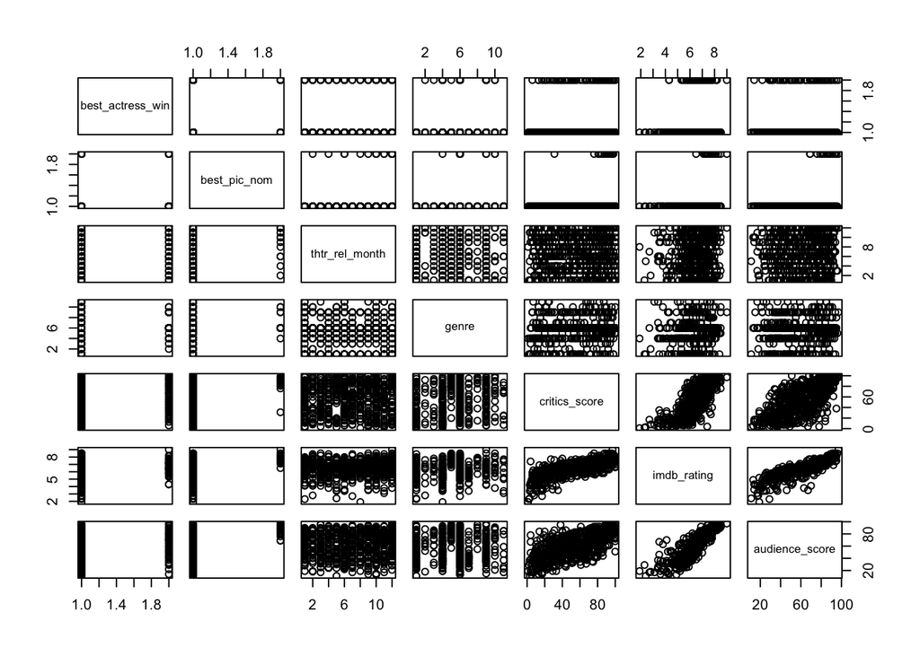

```r
m<-lm(formula = audience_score ~ genre + thtr_rel_month + imdb_rating +
    critics_score + best_pic_nom + best_actress_win, data = workingset)

pairs(~best_actress_win+best_pic_nom+thtr_rel_month+genre+critics_score+imdb_rating+audience_score,
      data=workingset)
```

Nearly Normal Residuals with mean 0

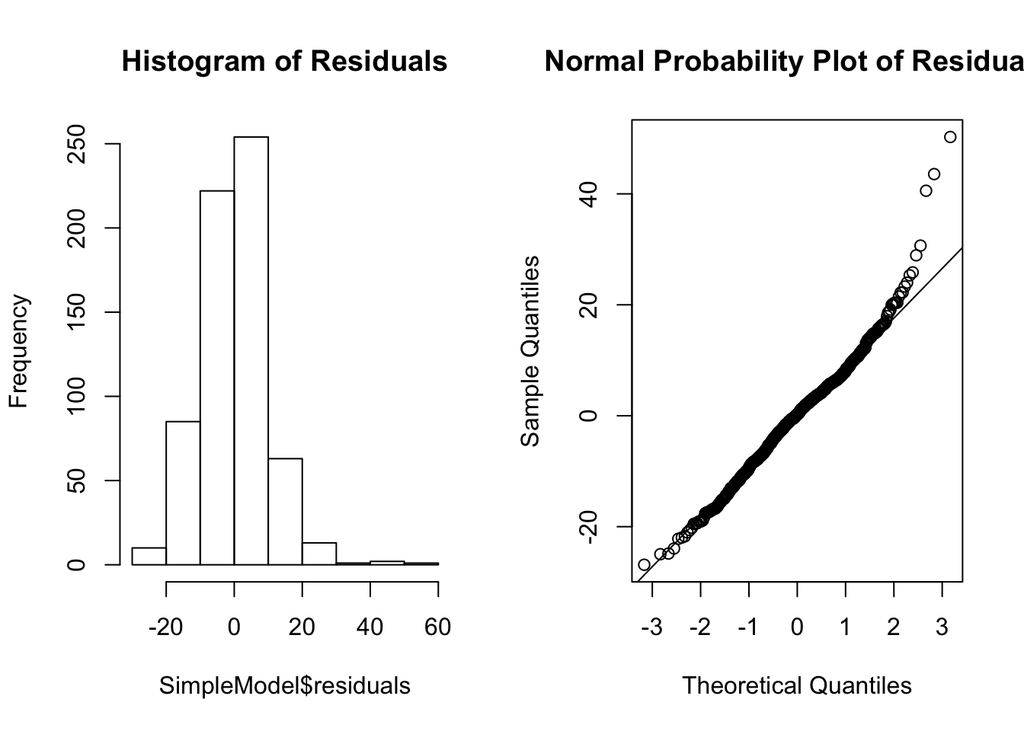

```r
par(mfrow=c(1,2))
hist(SimpleModel$residuals, main='Histogram of Residuals')
qqnorm(SimpleModel$residuals,main='Normal Probability Plot of Residuals')
qqline(SimpleModel$residuals)
```

An observation of the histogram of residuals above indicate a somewhat normal distribution with a strong right skew within the residuals. We see that most of the deviation occurs at the tail of the distriubtion when looking at the Q Q plot. It is clear that this is a linear (not binomial) distribution, so we will consider this test passed.

Constant Variability of Residuals

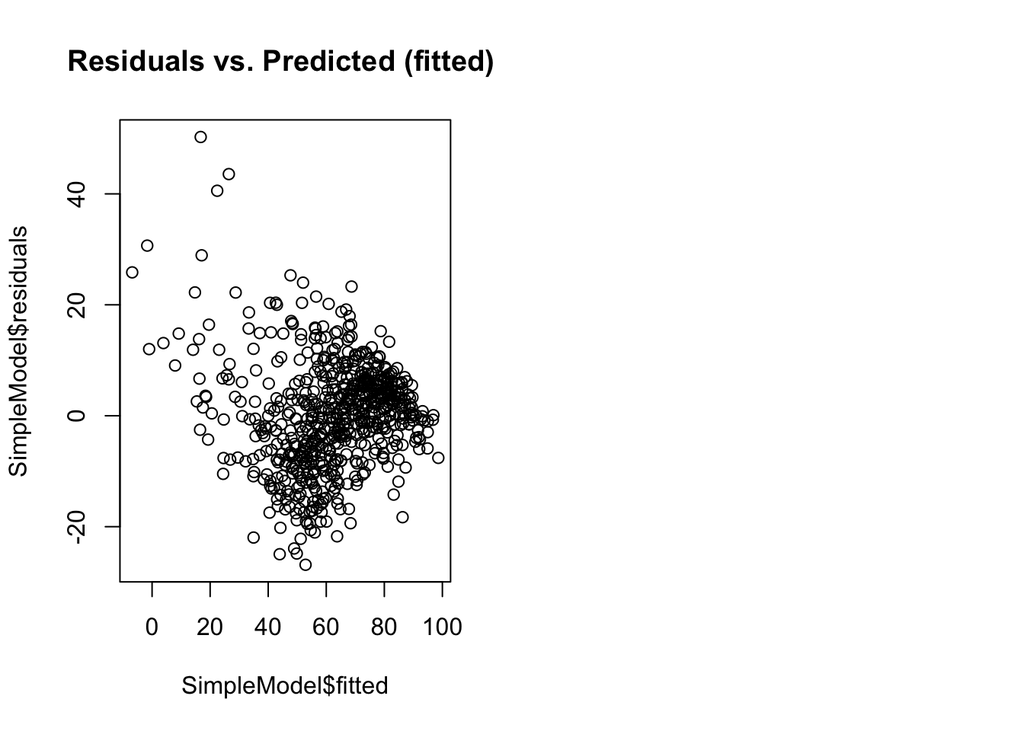

```r
par(mfrow=c(1,2))

plot(SimpleModel$residuals~SimpleModel$fitted,main='Residuals vs. Predicted (fitted) ')
```

Independent Residuals

The residuals on the chart below seem to be generally homoscedastic. However, there is some degree of heteroscedasticity in the left end of the above visualization; then the model will be less accurate when predicting lower values.

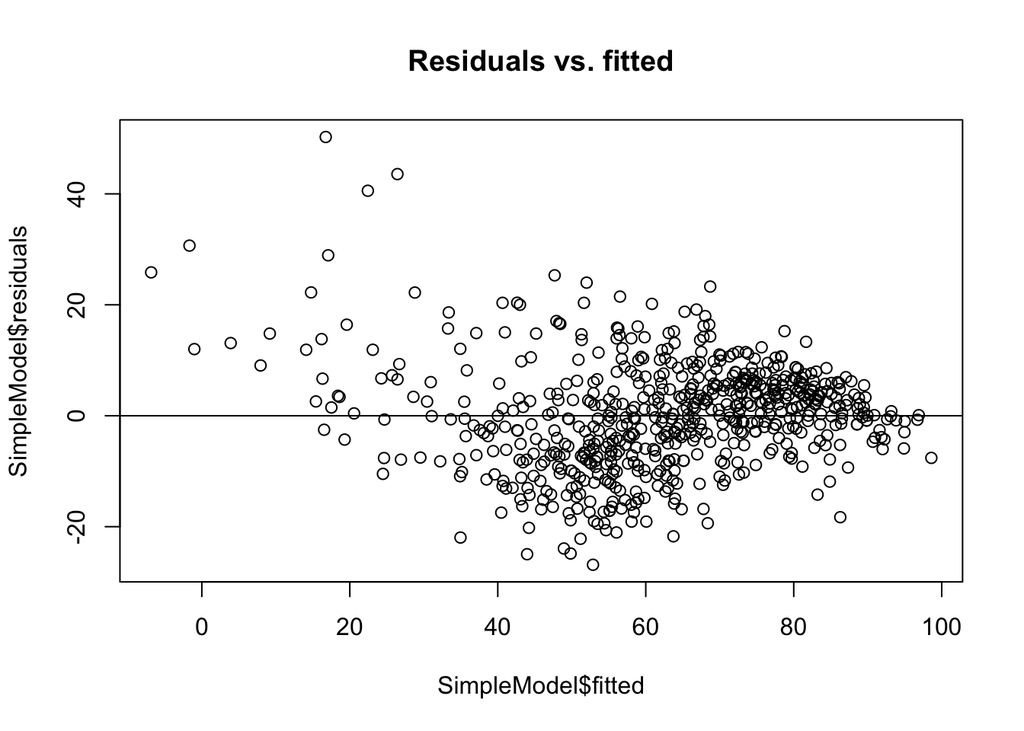

```r
plot(SimpleModel$residuals~SimpleModel$fitted,main="Residuals vs. fitted")
abline(0,0)
```

## Part 5: Prediction

We wanted to predict the audience score for a new movie that has not been used to fit the model. For the movie “Kung Fu Panda 3.” The data below, obtained from IMDB and Rotten Tomato represent each respective data point required to populate the SimpleModel.

Impressivley, the model was able to accuratrly created a range of possible values that caputred the actual audience score! The actual audience score for Kung Fu Panda 3 per Rotten Tomatoes was 79, and the model predeicted it to be 83 (rounded down to nearest whole number!) When considering the projected lower and upper boudns of the SimpleModel, we can see the predection falls within the bounds and is very close to the actual score!.

```r
KFP3<-data.frame(genre="Animation", thtr_rel_month=1,imdb_rating=7.2,critics_score=87,best_pic_nom="no",best_actress_win="yes")
predict(SimpleModel,KFP3)
```

```
##        1
## 83.28528
```

```r
predict(SimpleModel, KFP3, interval="predict")
```

```
##        fit      lwr      upr
## 1 83.28528 62.86262 103.7079
```

## Part 6: Conclusion

Potenially using the whole data set, or introducing external factors like net sales adjusted for inflation or social media data, we could have come up with an even more effecitve model, but that can be left the the sequel to this blockbuster!